# DATA 624 - HW1

### gasoline

Weekly gasoline production in the US from 1991 to 2017. Measured in million barrels per day.

There is a clear trend and seasonality. There could be early signs of cycling from 2000 to the end of the data.

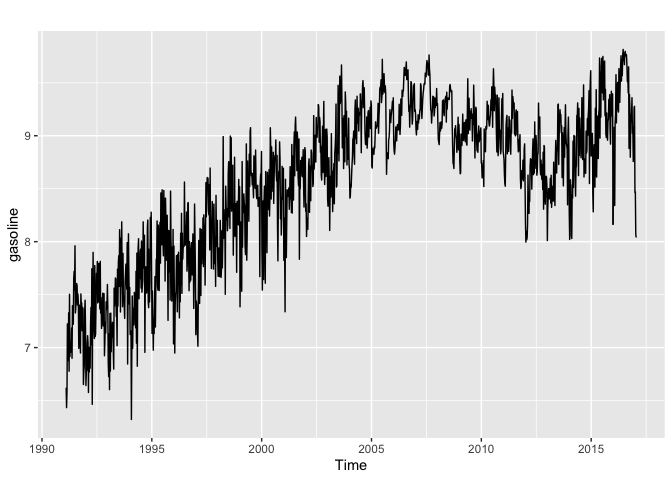

```r
autoplot(gasoline)
```

There seems to be a seasonal effect with a minimum around the 4th week and a maximum around the 30th week. That would a low in the beginning of February and a high in mid-July.

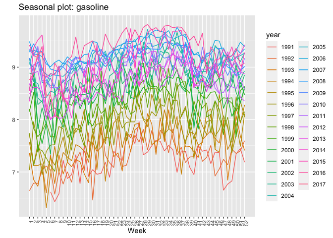

```r
ggseasonplot(gasoline) +
  theme(axis.text.x = element_text(angle = 90,
                                   hjust = 1,
                                   size = 8))
```

We need to change the frequency of this plot to weeks to plot. There is solid seasonality with production lowest in the winter and highest in the summer.

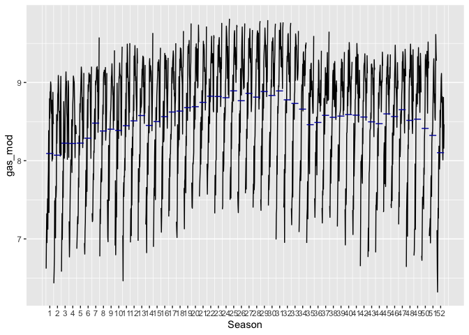

```r
gas_mod<- ts(gasoline, frequency = 52)
ggsubseriesplot(gas_mod)
```

Very strong autocorrealtion. Gas production seems to only go one-way when viewed in aggregate.

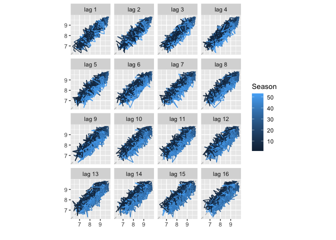

```r
gglagplot(gasoline)
```

Again, we see trended data with seasonality.

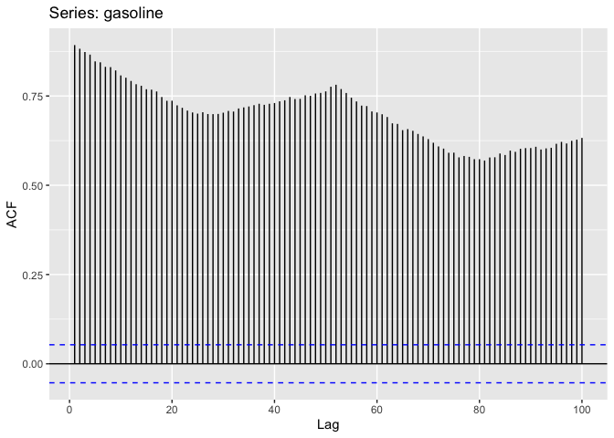

```r
ggAcf(gasoline, lag=100)
```